# Tutorial 0: (Optional) Startup with Modern C++

In this handout, we will go through some parts of C++ that will come up during the course.

# 1 Introduction

Published in 2020, the C++20 language specification has grown way beyond the C language and has many new idioms and programming paradigms that weren’t possible in the C language. Due to the sheer number of language features, C++ is often feared, as its complexity can sometimes result in unexpected behaviour or inexplicable error messages. However, when language features are properly understood, it often makes code much easier to write, sometimes even reaching Python-like levels of elegance.

In CS3211, we try to reduce the number of language features that we expose you to as it’s not necessary to use most of the complex features C++ has. However, if you happen to be more familiar with C++, feel free to use fancier features according to your best judgement!

However, we cannot and will not walk you through every part of C++ that you will need to use. Exploring C++ is a good experience and may help you pick up other languages more quickly in the future. If you get stuck during your explorations, feel free to approach your TA for help (but please remember to put in sufficient effort on your own first).

## 1.1 Popular resources

### 1.1.1 Google

As usual, Google can be a good reference. Here are some sample queries:

1. Upon seeing a massive wall of errors, find the first (few) error:
   - C++ error: ‘job’ has incomplete type
2. Get reference for a library function or class:
   - std deque cppreference
3. Look for explainer posts for a particular topic:
   - C++ memory model explained

### 1.1.2 cppreference

cppreference is a wiki for C++ and is usually nicer to look at than some of the alternatives.

Often, the reference is interleaved with all the diffs between each version of C++, see this for a particularly bad example of messy diffs: https://en.cppreference.com/w/cpp/string/basic_string/basic_string

There is a feature to only show the reference for a particular version of C++, but this requires creating an account. See this C++ Weekly video for details: https://youtu.be/eSDVVrjFh54?t=1030

### 1.1.3 Blog posts

It is important to ensure that the blog post is recent (i.e. probably not older than 2010).

### 1.1.4 Textbook

The textbook “C++ Concurrency in Action” has great explanations as well and would be a less risky way to find quality explanations compared to blog posts, although they can be rather long.

### 1.1.5 godbolt.org

Lets you try compiling, running, disassembling, and sharing short snippets of code in the browser. Great way to send code to your TA when asking for help!

https://godbolt.org/

## 1.2 Compiler support

As C++20 is really new, most compilers do not fully support it as of today. However, we will only really be using the new synchronization primitives added in C++20, which are supported by the latest compilers.

We recommend using either gcc 11 or clang 11 or newer on Linux, along with a recent standard library version (libstdc++ 11 or libc++ 11), as those versions support `std::*_semaphore`.

On Ubuntu, you can try installing `libc++-11-dev`, `libc++abi-11-dev`, and `clang-11`. If it doesn’t work, contact us.

## 1.3 Compiling your code

Remember to pass the flag `-std=c++20` and enable POSIX threads (`-pthread`) when compiling your code. Other useful flags are:

- `-O3`: Enable optimizations
- `-g`: Enable debugging symbols
- `-Wpedantic -Wconversion -Wall -Werror`: Enable a reasonable set of warnings
- `-c`: Compile to object file instead of executable (useful for code snippets)
- `-S`: Compile to assembly
- `-fsanitize=address`: Compile with AddressSanitizer
- `-fsanitize=thread`: Compile with ThreadSanitizer
- `-fsanitize=memory`: Compile with MemorySanitizer (only works on clang)

Example compilation command:

```
clang++ -g -std=c++20 -pthread -O3 \
  -Wpedantic -Wall -Wextra -Wconversion -Werror \
  queue.cpp main.cpp \
  -o main
```

### 1.3.1 Mac users

If you’re on a mac, then note that AppleClang (the default compiler on Mac) doesn’t support the new `<semaphore>` library in C++20, which is needed for this module. We’ve tried Homebrew’s GCC 11, but ran into some problems.

If you have the same issues, you may want to install a Linux VM or a docker container if you want to run code locally, or alternatively use the Linux ssh box allocated for CS3211.

Alternatively, you may want to rely on godbolt.org temporarily, but note that debugging with ThreadSanitizer on godbolt is not the best experience, as godbolt strips debugging information, so you won’t see any line numbers when a data race is detected.

### 1.3.2 Docker setup

1. Install Docker Desktop
2. `cd /path/to/code`
3. `docker run --name 3211 -v $PWD:/3211 -it -d ubuntu /bin/bash`
4. `docker exec 3211 bash -c "apt-get update && apt-get install clang-11 libc++-11-dev libc++abi-11-dev -y"`
5. `docker exec 3211 {your clang++-11 command to compile under /3211 dir, with -stdlib flag}`
6. `docker exec 3211 {your command to run stuff}`

Example compilation command:

```
# Remember to use the libc++ we installed
#   -stdlib=libc++
# files are at /3211
#   /3211/main.cpp \
#   -o /3211/main

docker exec 3211 \
  clang++-11 -g -std=c++20 -pthread -O3 \
  -Wpedantic -Wall -Wextra -Wconversion -Werror \
  -stdlib=libc++ \
  /3211/main.cpp \
  -o /3211/main
```

Example run:

```
docker exec 3211 /3211/main
```

# 2 A simple hello world program

We start off with a breakdown of a simple hello world program. Please try to compile and tweak this code to try and gain a better understanding of it!

Godbolt: https://godbolt.org/z/f6soPdK6f

```cpp
#include <chrono>
#include <iostream>
#include <string>
#include <thread>

std::string hello = "Hello";

void print_hello() {
  std::this_thread::sleep_for(std::chrono::seconds(1));
  std::cout << hello << std::endl;
}

int main() {
  std::string world("World");

  std::thread thread1(print_hello);
  std::thread thread2(
      [](std::string name) {
        std::this_thread::sleep_for(std::chrono::seconds(2));
        name += "!";
        std::cout << name << std::endl;
      },
      world);

  thread1.join();
  thread2.join();

  return 0;
}

// Output after 1 second: Hello
// Output after 2 seconds: World!
```

## 2.1 Breakdown

### 2.1.1 Includes: `#include <chrono>` …

This is the same as C and simply copy-pastes the named file into the current source file. When you see a function or class on cppreference that you would like to use, look for a line near the top that tells you which file that function or class is provided in:

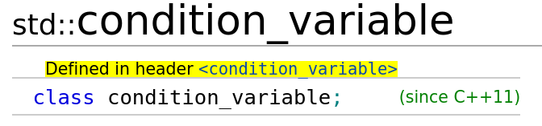

### 2.1.2 Main function: `int main() { ... }`

Just like in C, main is the entry point to the program. It optionally accepts argc and argv and returns the status code of the program. https://en.cppreference.com/w/cpp/language/main_function

### 2.1.3 Namespaces: `std::`

In order to prevent conflicts, everything in the standard library is placed in the `std` namespace, and we need to prepend `std::` to use it. While there exists a directive to import all names from a namespace into the current scope, it’s usually not a good idea to use them unless there is a specific reason to.

Namespaces can be nested, for example `std::this_thread::` is a namespace inside `std::`.

C++ Weekly 305: Stop using `using namespace`: https://www.youtube.com/watch?v=MZqjl9HEPZ8

This creates a local variable named `world` of type `std::string`. To initialize the string, the constructor for `std::string` is called, allocating a sufficiently large buffer on the heap[^1] to store the bytes of the string in. In particular, overload (5) in cppreference. https://en.cppreference.com/w/cpp/string/basic_string/basic_string

### 2.1.5 Global variables: `std::string hello = "Hello";`

Don’t be fooled by the `=` sign here! This is just another way of calling single argument constructors meant to make the syntax look cleaner, and it’s pretty much[^2] equivalent to the following:

```cpp
std::string hello("Hello");
```

As this is in the global scope, this creates a global variable instead of a local one. The code to initialize this variable is called even before the main function is entered.

### 2.1.6 Starting threads: `std::thread thread1(print_hello);`

This creates a local variable named `thread1` which represents the thread, and the constructor called is overload (3) in cppreference. https://en.cppreference.com/w/cpp/thread/thread/thread[^3]

This particular constructor starts a thread that executes `print_hello(args...)` at the same time the thread object is created, where `args` are additional arguments passed to the constructor. In this case, we pass no additional arguments, so this thread executes `print_hello()`.

### 2.1.7 Passing arguments to threads: `std::thread thread2(<lambda>, world);`

In the next line, we start the second thread, but since there is one additional argument, the thread executes `<lambda>(world)` when it is started.

### 2.1.8 Lambdas: `[](std::string name) { ... }`

C++ has syntax sugar for writing functions in expressions. This is similar to if we had declared a new function object and passed it to the thread constructor.

```cpp
std::thread thread2([](std::string name) { ... }, world);

// similar to

struct MyLambda {
  void operator()(std::string name) const { ... }
};
std::thread thread2(MyLambda{}, world);
```

Lambdas may also capture variables, which corresponds to passing additional fields to be stored in the function object:

```cpp
std::thread thread3([world]() { ... });

// similar to

struct MyLambda {
  std::string world;

  void operator()() const { ... }
};
std::thread thread2(MyLambda{world});
```

### 2.1.9 Pass-by-value

You’ll notice that this function takes in a parameter named `name`. By default, arguments are passed by value. What this means is that the string `name` is a copy, not a reference, of the original string `world`. Thus, when the string `name` is modified, the original string `world` living in the main function’s stack frame is left untouched.

### 2.1.10 Function calls: `std::this_thread::sleep_for(std::chrono::seconds(1));`

Pretty self-explanatory.

https://en.cppreference.com/w/cpp/thread/sleep_for

The argument is a `std::chrono::duration`, and there are many ways of constructing such a duration.

https://en.cppreference.com/w/cpp/chrono/duration

### 2.1.11 Printing to stdout: `std::cout << hello << std::endl;`

This is the syntax to first print hello to stdout, then the magic object `std::endl`. `std::endl` is shorthand for printing a newline, then flushes the buffer. This works as the standard library has overloaded the `<<` operator so that this gets translated to the appropriate lower level print functions, depending on the type of the RHS.

You may also print to stderr by replacing `std::cout` with `std::cerr`.

### 2.1.12 Scope exit calls destructors: `return 0;`

Now that we have reached the end of the main function, we return 0 and this causes the execution to leave the scope where we have defined some local variables (`world`, `thread1`, `thread2`). Upon scope exit, the destructors of each local variable are called in the reverse order that they were constructed.

So upon scope exit, we call the destructors of `thread2`, then `thread1`, then finally `world`.

Since world is a `std::string`, the destructor deallocates[^4] the buffer containing the bytes of the string for us, which is why we did not have to call any `new`/`malloc` or `delete`/`free` explicitly.

Note that control flow also introduces scope:

```cpp
if (true) {
  std::string hi = "hi there";
} // hi is destructed here
```

# 3 Classes and objects

Now that our toes are wet, let’s flesh out how C++ classes and objects work.

Full godbolt: https://godbolt.org/z/9zzvbWfdz

## 3.1 Defining a class

```cpp
struct A {
  char x;
  std::string y; // 7 bytes padding is added before y to satisfy alignment
  std::string saga;
};
```

At its most basic form, C++ classes can be defined just like C structs, and member access works the usual way.

### 3.1.1 `class`

The `class` keyword may also be used to define classes, but this makes everything `private` by default. We can make things `public` similar to Java.

```cpp
class A {
  char a_private_member;
 public:
  char x;
  std::string y; // 7 bytes padding is added before y to satisfy alignment
  std::string saga;
};
```

### 3.1.2 Size, alignment, and padding

Reference: https://pzemtsov.github.io/2016/11/06/bug-story-alignment-on-x86.html

In C and C++, each type has a size (which we can get via `sizeof`) and an alignment (which we can get via `alignof`). These two properties tell us how much memory is required to store an object, as well as what addresses that memory region may begin on.

Alignment exists because most hardware architectures have operations that only work when memory alignment conditions are met (e.g. vector operations), or slow down drastically when memory is not aligned (e.g. memory reads). To support this, many languages impose alignment conditions such that when they are broken, the language is allowed to let your program crash, slow down, read the wrong address, etc.

For example, a C++ implementation on x86_64 might have the alignment of a 32-bit integer as 4 bytes (or 32-bit). Reading an int from an unaligned address is undefined behaviour according to the language specification. On x86_64, this is typically just poorer performance[^5].

So in the following struct, C++ ensures that the `int` lives on 4-byte aligned addresses by ensuring that the struct itself also has an alignment of 4 bytes, and adds 3 bytes of padding between the `char` and `int`.

```cpp
struct X {
  char a;
  int b; // 3 bytes of padding before b
};

// sizeof(X) = 8
// alignof(X) = 4, so addresses of objects of type X are always multiples of 4
```

## 3.2 Default constructor and destructor

### 3.2.1 Object lifetime and “RAII”

Reference: https://en.cppreference.com/w/cpp/language/raii

Unlike C however, C++ comes with a notion of an object lifetime (much looser than Rust’s rules for lifetime), where a constructor is called at the start of each object’s lifetime, and a destructor is called at the end of its lifetime.

```cpp
void demo1() {
  A a; // Start of lifetime of a
  {
    A b; // Start of lifetime of b
  } // End of lifetime of b
  A c; // Start of lifetime of c
  // End of lifetime of c
  // End of lifetime of a
}
```

This enables a pattern commonly known as RAII:

- **R**esource
- **A**cquisition
- **I**s
- **I**nitialization

This refers to tying “resources” to specific object lifetimes. When a resource is acquired, a handler object is constructed that owns said resource. When that object goes out of scope and thus reaches the end of its lifetime, its destructor cleans up said resource.

Since this pattern requires you to write your own custom destructor, some prefer the acronym RRID instead, which emphasizes the end of an object’s lifetime instead of its beginning.

- **R**esource
- **R**elease
- **I**s
- **D**estruction

For example, `std::string` may allocate a buffer to hold its characters during construction or over the course of many operations, and when the `std::string` goes out of scope, its lifetime ends, thus calling its destructor. The destructor then deallocates the buffer, ensuring that no memory is leaked.

### 3.2.2 Defining custom constructor and destructor

Let’s define custom constructors and destructors for our class. Let’s store the “story” of how our struct’s data came to be in the `saga` field.

```cpp
A() : x('1'), y(), saga("default constructed") {
  std::cout << "Default constructor called" << std::endl;
}

~A() { std::cout << "Destructor called, object was " << saga << std::endl; }
```

With this constructor and destructor, we see the output matches the start and ends of each object’s lifetime.

```
Default constructor called
Default constructor called
Destructor called, object was default constructed
Default constructor called
Destructor called, object was default constructed
Destructor called, object was default constructed
```

### 3.2.3 Default constructor

The syntax of a constructor is like a function named exactly like the class with no return type. A default constructor is a constructor that takes no arguments.

```cpp
// Basic form of the default constructor,
// /* ... */ is run after members are constructed
// (from first member to last member).
type() { /* ... */ }

// This time, we can modify how exactly each member is constructed
// by passing the constructor arguments to each member
// after a colon and before the opening brace.
type() : member(constructor args), member2( ... ), ... { /* ... */ } // B
```

In the example above, we wrote a default constructor for `A()` that first constructs its members by passing `'1'` to the constructor for `char,` nothing to the constructor for `y,` and “default constructed” to the constructor of `saga`. Once the members have been constructed, the body of `A()` is run, which prints “Default constructor called” to stdout.

### 3.2.4 Destructor

Similar to the default constructor but with a tilde `~` before the class name.

```cpp
~type() { /* ... */ }
```

This time, `/* ... */` runs first, and then the destructors of each member are called (from last member to first member).

## 3.3 Additional constructors

As you may have noticed, we frequently do not use default constructors when creating objects like `std::string` or `std::thread`, instead passing data at construction. For example:

```cpp
std::string s("Hello world!");
```

If we want to create such additional constructors, we simply add our own function parameters into the constructor declaration.

```cpp
A(int i)
    : x('1' + (char)i),
      y("This string was constructed with A(int)"),
      saga("A(int) constructed") {
  std::cout << "A(int) constructor called" << std::endl;
}
```

## 3.4 References

As mentioned before, C++ passes objects by value. Let’s break down the following demo:

```cpp
void change_x_bad(A a) { a.x = 'C'; }
void change_x_good(A& a) { a.x = 'C'; }

void demo2() {
  A a;
  change_x_bad(a);
  std::cout << "Mutate pass by value: " << a.x << std::endl;

  {
    A a_copy = a;
    a_copy.x = 'C';
    std::cout << "Mutate copy: " << a.x << std::endl;
    a = a_copy;
    std::cout << "Copy mutated back to a: " << a.x << std::endl;
  }

  A b;
  change_x_good(b);
  std::cout << "Mutate pass by reference: " << b.x << std::endl;

  A c;
  A& c_ref = c;
  c_ref.x = 'C';
  std::cout << "Mutate reference: " << c.x << std::endl;
}
```

Output:

```
Default constructor called
Destructor called, object was default constructed
Mutate pass by value: 1
Mutate copy: 1
Copy mutated back to a: C
Destructor called, object was default constructed
Default constructor called
Mutate pass by reference: C
Default constructor called
Mutate reference: C
Destructor called, object was default constructed
Destructor called, object was default constructed
Destructor called, object was default constructed
```

Let’s break this down.

```
// A a;
Default constructor called
// } of change_x_bad destructs argument named a
Destructor called, object was default constructed
// std::cout << ...
Mutate pass by value: 1
```

First we construct an object named `a`, and pass that object to `change_x_bad` by value. `change_x_bad` tries to modify `x`, but it only modifies its local copy. Furthermore, we can see that this local copy gets destroyed in the second line of the output, even though the original object `a` in `demo2` is left untouched, as shown by the third line of the output.

```
// A a_copy = a; prints nothing
// std::cout << ...
Mutate copy: 1
// a = a_copy; prints nothing
// std::cout << ...
Copy mutated back to a: C
// } destructs a_copy
Destructor called, object was default constructed
```

Trying to mutate an object passed by value is similar to performing a copy as shown in the second block of code in `demo2`. Here, it’s clearer why mutating the copy does not mutate the original object.

The reason why we have a “Destructor called” line in the output even though we don’t have a corresponding “constructor called” line is because we have not yet overridden the copy constructor, something we’ll get to shortly.

If we’d like a function to mutate an object, then we can instead pass it by reference by adding an ampersand `&` after the type name in the parameter list, for example `A& a`.

```
// A b;
Default constructor called
// } of change_x_good prints nothing as nothing to destruct
// std::cout << ...
Mutate pass by reference: C
```

In the third block of code, we again construct a new object named `b`, and pass it by reference to `change_x_good`. This time, when `change_x_good` returns, we don’t see any “Destructor called” line because there is no copy made. The `a` variable in `change_x_good` *refers* to the `b` object in the `demo2` scope. When we read `b.x` after the function call, we see that its value has indeed changed to `'C'`.

```
// A c;
Default constructor called
// std::cout << ...
Mutate reference: C
```

Again, we can simulate this without a function call as we can also create reference variables with `A& c_ref = c;`. We see that mutating the reference causes the change to show up in the original object as expected.

```
// } of demo2 destructs c, b, a in that order.
Destructor called, object was default constructed
Destructor called, object was default constructed
Destructor called, object was default constructed
```

## 3.5 Rule of 3

Reference: https://en.cppreference.com/w/cpp/language/rule_of_three

Earlier, we noticed that copies were being created and destroyed, but since we did not define our own copy constructor, we saw a “Destructor called” line that did not have a corresponding “constructor called” line.

This is because we broke the “Rule of 3”. We wanted to create a class where object lifetimes would become visible in stdout through logging messages, and thus we’ve started doing interesting things at the beginning and end of object lifetimes. By not creating a custom copy constructor, we missed a case where an object’s lifetime could begin.

Thus, the “Rule of 3” states that if a class requires either a custom destructor, copy constructor, or copy assignment operator, then it almost always needs all 3.

## 3.6 Copy constructor and copy assignment operator

Let’s fix that by defining a custom copy constructor and copy assignment operator:

```cpp
struct B {
  // ... members, default ctor, and dtor ...

  B(const B& other) // copy constructor
      : x(other.x),
        y(other.y),
        saga("copy constructed from object that was " + other.saga) {
    std::cout << "Copy constructor called" << std::endl;
  }

  B& operator=(const B& other) { // copy assignment operator
    std::cout << "Copy assignment called" << std::endl;
    x = other.x;
    y = other.y;
    saga = "(" + saga + ") then set to object that was (" + other.saga + ")";
    return *this;
  }
};
```

Here, we also define the copy assignment operator at the same time. In C++, you almost always want to define these two functions together.

### 3.6.1 Copy constructor

The syntax is exactly like a constructor that has a single `const` (immutable) reference of the type as the only parameter.

```cpp
type(const type& other) { ... }
```

### 3.6.2 Copy assignment operator

The syntax is like a member function named `operator=`, but it should take in a single `const` reference of type as a parameter, and return a reference of the type.

```cpp
type& operator=(const type& other) { ... return *this; }
```

The operator should return `*this`. This enables us to “chain” assignment statements.

```cpp
a = b = c;
// same as
a = (b = c);
```

### 3.6.3 Demo

With the copy constructor and assignment operator, we can demonstrate how the various constructors we’ve defined so far can be used.

```cpp
void demo3() {
  B a; // Default constructor, no arguments
  B a_copy = a; // Copy constructor, argument is another instance of B
  B b(1); // Custom constructor, int as argument
  b = a; // Copy assignment operator, an assignment whose RHS is another instance of B
}
```

now produces the following output:

```
Default constructor called
Copy constructor called
B(int) constructor called
Copy assignment called
Destructor called, object was (B(int) constructed) then set to object that was (default constructed)
Destructor called, object was copy constructed from object that was default constructed
Destructor called, object was default constructed
```

## 3.7 Move constructor and move assignment operator

To round things off, we briefly show the syntax for move operations, but if you would like a more detailed explanation of what move is and how it should be used, there is a good explanation in Appendix A of the textbook “C++ Concurrency in Action”, starting at page 354. However, note that while the book does not show the assignment operators (likely to save space), you should always define the corresponding assignment operators whenever defining a custom copy or move constructor.

```cpp
struct C {
  // ... previously defined ctors and operators ...

  C(C&& other) // Takes in TWO ampersands
      : x(std::move(other.x)),
        y(std::move(other.y)),
        saga("move constructed from object that was " + other.saga) {
    std::cout << "Move constructor called" << std::endl;
  }

  C& operator=(C&& other) { // Takes in TWO ampersands, returns ONE ampersand
    std::cout << "Move assignment called" << std::endl;
    x = std::move(other.x);
    y = std::move(other.y);
    saga = "(" + saga + ") then set to object that was (" + other.saga + ")";
    other.saga = "(" + other.saga + ") then moved from";
    return *this;
  }
};

void demo4() {
  C c1;
  std::cout << "c1: " << c1.x << ":" << c1.y << std::endl;
  C c2(1);
  std::cout << "c2: " << c2.x << ":" << c2.y << std::endl;
  C c3 = c2;
  std::cout << "c3: " << c3.x << ":" << c3.y << std::endl;
  c3 = c1;
  std::cout << "c3: " << c3.x << ":" << c3.y << std::endl;
  c3 = std::move(c2);
  std::cout << "c2: " << c2.x << ":" << c2.y << std::endl;
  std::cout << "c3: " << c3.x << ":" << c3.y << std::endl;
}
```

Output:

```
Default constructor called
c1: 1:
C(int) constructor called
c2: 2:This string was constructed with C(int)
Copy constructor called
c3: 2:This string was constructed with C(int)
Copy assignment called
c3: 1:
Move assignment called
c2: 2:
c3: 2:This string was constructed with C(int)
Destructor called, object was ((copy constructed from object that was C(int) constructed) then set to object that was (default constructed)) then set to object that was (C(int) constructed)
Destructor called, object was (C(int) constructed) then moved from
Destructor called, object was default constructed
```

### 3.7.1 Move-only types

When a class only defines a move constructor / assignment operator but NOT a copy constructor / assignment operator, it can only be moved and not copied. This is what types like `std::thread` and `std::unique_ptr` do. When using such types, it’s important to ensure ownership is properly transferred, e.g. using `std::move`.

# 4 STL Containers

STL Containers reference, which contains a list of the STL container types:

https://en.cppreference.com/w/cpp/container

While you may need to implement your own concurrent data structures, you will probably also want to make use of the standard library’s single-threaded containers when implementing portions of your algorithms.

For the most part, using these containers isn’t very difficult, so in this section we provide a small cookbook. When you start using these for yourself, referring to cppreference will be very helpful.

STL stands for “Standard Template Library”, and has two parts: containers and algorithms. The word “Template” in STL refers to the fact that the classes provided for us to use are generic, and can be instantiated to a specific type depending on your needs.

## 4.1 Instantiating containers of particular types

```cpp
std::vector<int> vector_of_ints;
std::vector<std::string> vector_of_strings;
std::unordered_map<std::string, int> map_of_string_to_int;
```

To create a container of a particular type, put the types you need in angle brackets, and “pass” them to the type. These parameters are called template parameters, and an explanation of what they mean are on the cppreference page of each container type.

For example, for `std::vector`, https://en.cppreference.com/w/cpp/container/vector

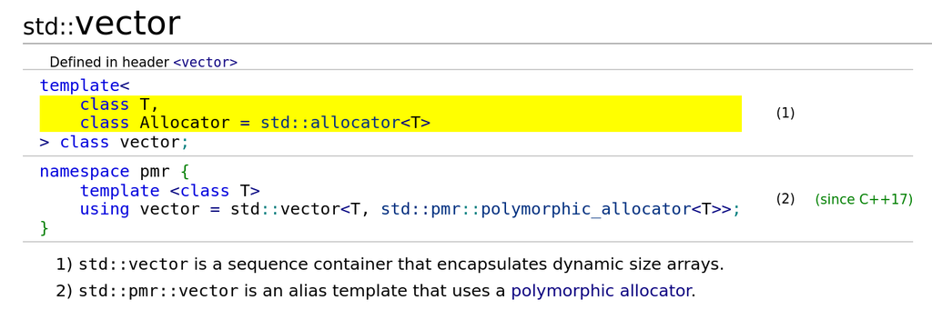

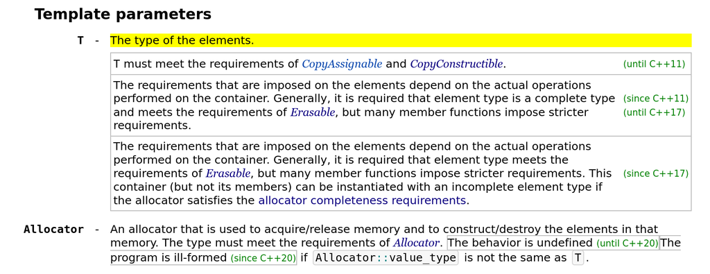

Thus, we know that `std::vector` takes in two template parameters, where the second one is defaulted to an allocator class, and that `std::vector<int>` is a vector whose elements have type `int`.

Another example, for `std::queue`, https://en.cppreference.com/w/cpp/container/queue

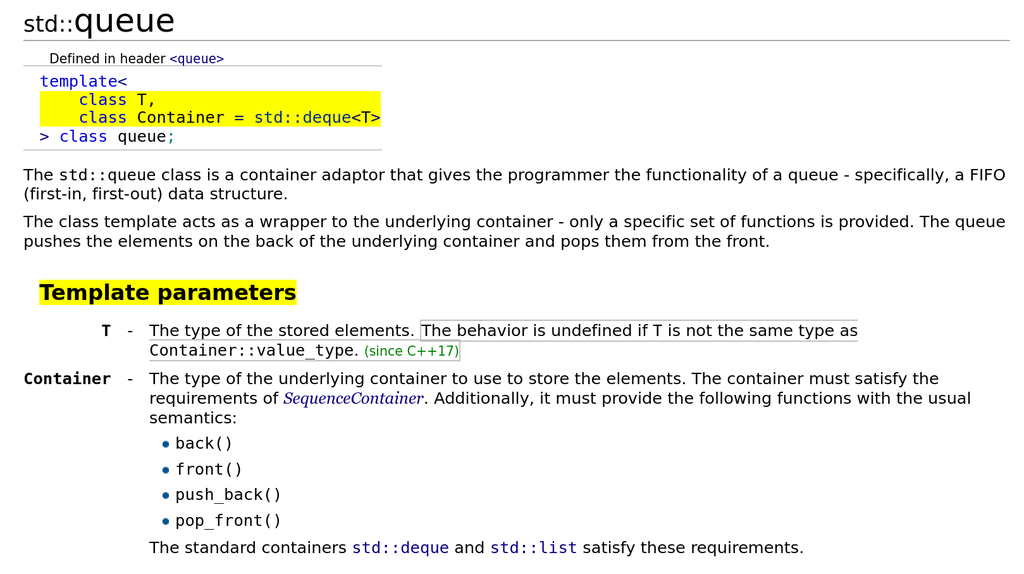

We see that `std::queue` also takes in two template parameters, but this time, the second parameter should be another container type, for example `std::deque` in this case. Thus `std::queue<int, std::list<int>>` is a queue whose underlying container is a doubly-linked list.

## 4.2 Inserting to containers

```cpp
vector_of_ints.push_back(1);
vector_of_strings.emplace_back("Hello world!");
map_of_string_to_int.insert({"one", 1});
map_of_string_to_int.emplace("two", 2);
```

STL containers typically use the same few words for their operations. `push_back` applies to most sequence containers (like `std::vector`, `std::list`, etc.) that have a “back” side. `insert` is similar to `push_back` but either allows you to specify where in a sequence container to insert it in, or used for (un)ordered containers like `std::unordered_map`. As usual, refer to the class’s reference page for the list of operations you may use.

### 4.2.1 Push/insert vs emplace

Reference: https://abseil.io/tips/112

In the example above, I showed two ways of inserting to the back of a vector, `push_back` and `emplace_back`.

The difference is subtle. `push_back` takes a fully constructed object as input, then copies or moves that object into the container. On the other hand, `emplace_back` takes in the arguments to the element’s constructor as input, and constructs the object directly into the container.

To illustrate, we can discuss the difference between the following lines:

```cpp
vector_of_strings.push_back("Hello world!");
vector_of_strings.emplace_back("Hello world!");
vector_of_strings.emplace_back("abcde", 3);
```

In the first line, `push_back` expects a `std::string` as input. However, what was provided is a string literal, so C++ will call the 5th constructor of `std::string` to get a temporary `std::string` object. This object is then moved into the vector, and then the temporary string is destructed.

In the second line, the arguments that `emplace_back` can take depends on the constructors of `std::string`. Since we have passed a single string literal, `emplace_back` will call the 5th constructor of `std::string` to create the string directly in the vector, without creating any temporaries.

In the third line, the arguments we passed to `emplace_back` matches the 4th constructor of `std::string`, and thus the string containing the bytes “abc” will be pushed into the vector.

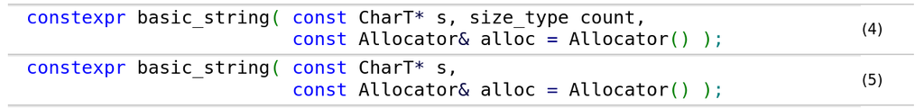

However, there are many times where using `emplace_back` is not needed and sometimes even causes bugs.

```cpp
vector_of_vector_of_int.push_back(1);
vector_of_vector_of_int.emplace_back(1);
```

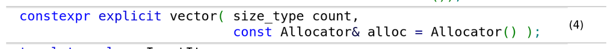

Recommendation: Use `push_back` when you just want to put something in a container, use `emplace_back` when you’re creating something new and you are very aware that you are in fact calling a constructor.

## 4.3 Reading or mutating containers

```cpp
// Return index 5 with no bounds checking.
vector_of_ints[5];

// If 5 is in bounds, return index 5, otherwise an exception is thrown.
vector_of_ints.at(5);

// If key "one" exists, return corresponding value,
// otherwise an exception is thrown.
map_of_string_to_int.at("one");

// If key "one" exists, return corresponding value,
// otherwise it's added with a default constructed value,
// and that value is returned
map_of_string_to_int["one"];
```

These expressions may also be assigned to, and bounds checking also applies.

```cpp
// Mutate or create new entry mapping "one" to 5
map_of_string_to_int["one"] = 5;

// Mutate existing entry for "one" to 5,
// throws exception if entry does not exist
map_of_string_to_int.at("one") = 5;
```

## 4.4 Iterating through containers

Reference: https://en.cppreference.com/w/cpp/language/range-for

In this section we show how the syntax of a range based for loop works, which all containers support as a means of iteration.

Simplifying slightly, range-based for loops are just a syntax sugar for using the lower level `.begin()` and `.end()` iterators that containers support. (See the reference for exact details). It more or less works in the following way:

```cpp
for (type varname : container) { /* ... */ }
// syntax sugar (ish) for:
iterator end = container.end();
for (iterator it = container.begin(); it != end(); ++it) {
  type varname = *it; // Access element pointed to by the iterator
  /* ... */
}
```

I’m showing you how this desugaring works since you may occasionally want to fall back to this lower level iterator syntax to perform certain operations with more finesse. But in the vast majority of cases, range based for loops are better.

Now we show some examples of how this feature can be used, and some potential gotchas.

```cpp
// Iterate by value.
for (int i : vector_of_ints) { /* A */ }

// Iterate by value, but an implicit conversion happens
// when the element pointed by the iterator is accessed,
// converting the int to a double silently. Be careful!
for (double d : vector_of_ints) { /* B */ }

// Iterate by value, and note in particular this means
// each string will have to be copied out into s.
for (std::string s : vector_of_strings) { /* C */ }

// Iterate by (mutable) reference, so no copy is made.
// Since s is a mutable reference, you could change s
// and the change will be reflected in the vector.
for (std::string &s : vector_of_strings) { /* D */ }

// Iterate entries (key-value pairs) by (mutable) reference.
for (std::pair<const std::string, int> &entry : map_of_string_to_int) { /* E */ }

// Same as E, but the type is provided by the class
// instead of looked up in cppreference.
for (std::unordered_map<std::string, int>::value_type &entry : map_of_string_to_int) { /* F */ }

// Same as E, but uses type inference.
// This way, we can avoid performing accidental conversions!
for (auto &entry : map_of_string_to_int) { /* G */ }

// Iterate entries by immutable reference.
for (const auto &entry : map_of_string_to_int) { /* H */ }
```

In general, you will want to prefer the following ways of iterating through a container:

- A: If you’re just accessing a container of “simple” type, where a by-value is better than by-reference. Using type inference here is also a good idea.
- G: If you intend to mutate all entries of a container in place.
- H: If you intend to iterate over a container where copying is expensive (e.g. `std::string`)

# 5 ThreadSanitizer

We won’t do a breakdown for this demo, but feel free to compile it with ThreadSanitizer and play around with the race detection.

Godbolt: https://godbolt.org/z/4YhzYnr65

```cpp
#include <thread>

int raced;
int result;

int main() {
  std::thread t0([]() { raced = 0; });
  std::thread t1([]() { raced = 1; });
  std::thread t2([]() { result = raced; });

  t0.join();
  t1.join();
  t2.join();

  return result;
}
```

[^1]: This allocation does not actually happen because of small string optimization, where the bytes of sufficiently small strings may be stored directly in the `std::string` struct itself instead of on the heap. But for now, it illustrates the point better if we pretend that this allocation is on the heap.
[^2]: There is a tiny difference, which is that this is a copy initialization instead of a direct constructor call. In particular, constructors marked explicit will reject this syntax. https://en.cppreference.com/w/cpp/language/copy_initialization
[^3]: thread thread thread
[^4]: Just as allocation may not happen if the string is sufficiently small, deallocation may not happen if no buffer was allocated in the first place.
[^5]: x86_64 has alignment checking as an option at the system level. When enabled, unaligned accesses cause an alignment exception (a hardware exception) to be generated, which on POSIX systems typically result in a SIGSEGV or SIGBUS. This is almost never enabled, however.